# Network Filtering Analysis

Greg Cary

2023-02-14

```r
library(synapser)
# library(paxtoolsr)
# library(org.Hs.eg.db)
# library(clusterProfiler)
# library(HotNetvieweR)
library(igraph)
library(tidygraph)
library(tidyverse)

source(paste0(here::here(),'/../biodom_tally.R'))
source(paste0(here::here(),'/../biodom_enr.R'))
source(paste0(here::here(),'/../biodom_enr_plots.R'))

theme_set(theme_bw())
```

Grab relevant data from synapse, including:  
1) Target Risk Scores (syn25575156) and Omics Scores (syn22758536)  
2) Biodomain Definitions (syn25428992)  
3) Pathway Commons Full Graph, v12 (syn51080932)  
4) Human Protein Atlas tissue immunohistochemistry micro array data (syn51074598)  
5) RNA Brain GTEx (syn51074639)  
6) AMP-AD cohort pairwise partial correlations ([ROSMAP](https://www.synapse.org/#!Synapse:syn51061790), [Mayo](https://www.synapse.org/#!Synapse:syn51061614), [MSBB](https://www.synapse.org/#!Synapse:syn51061324)); these are quite large! (> 6 GB), wait to load until performing this analysis  
7) SEA-AD single cell data (syn51080312); this is a large file (> 2 GB), wait to load until performing this analysis

```r
synLogin()

# target risk scores
scores <- read_csv(synTableQuery('select * from syn25575156', includeRowIdAndRowVersion = F)$filepath)
omics <- read_csv(synTableQuery('select * from syn22758536',  includeRowIdAndRowVersion = F)$filepath)

# biological domain annotations
biodom <- full_join(
  # biodomains
  readRDS(synGet('syn25428992')$path),
  # domain labels
  read_csv(synGet('syn26856828')$path),
  by = c('Biodomain'='domain')
) %>%
  mutate(Biodomain = case_when(Biodomain == 'none' ~ NA_character_, T ~ Biodomain))

# pathway commons graph
net <- igraph::read_graph(synGet('syn51080932')$path, format = 'graphml')

# Human protein atlas info
tissue.array <- read_csv(synGet('syn51074598')$path)
brain.gtex <- read_csv(synGet('syn51074639')$path)
```

# Pathway Commons Network

Extract the core NW tables

```r
net.tbl <- igraph::as_data_frame(net)

v.attr <- tibble( na = vertex.attributes(net) ) %>%
  t() %>% as_tibble(rownames = NA, .name_repair = 'unique') %>% unnest(everything()) %>%
  rename_with(., ~names(vertex.attributes(net)), everything())

e.attr <- tibble( ea = edge.attributes(net) ) %>%
  t() %>% as_tibble(rownames = NA, .name_repair = 'unique') %>% unnest(everything()) %>%
  rename_with(., ~names(edge.attributes(net)), everything())
```

Specify the directed-edge types to filter the Pathway Commons graph

```r
directed_edge_types = c("catalysis-precedes",
                        "controls-expression-of",
                        "controls-phosphorylation-of",
                        "controls-state-change-of",
                        "controls-transport-of"
                        )

# dir.net <- graph_from_data_frame(d = net.tbl %>% filter(interaction %in% directed_edge_types), directed = T)
```

How many edges from each source?

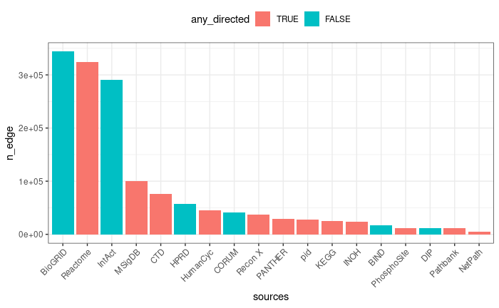

```r
bind_cols(
    sources = str_split(net.tbl$sources,',') %>% unlist %>% unique,
    n_edge = map_dbl(
        str_split(net.tbl$sources,',') %>% unlist %>% unique,
        ~ net.tbl %>% filter(grepl(.x, sources)) %>% nrow() ),
    any_directed = map_lgl(
        str_split(net.tbl$sources,',') %>% unlist %>% unique,
        ~ net.tbl %>%
            mutate(directed = if_else(interaction %in% directed_edge_types, 'dir','undir') ) %>%
            filter(grepl(.x, sources)) %>% pull(directed) %>% any(. == 'dir')
    )
) %>%
  mutate(any_directed = if_else(is.na(any_directed), FALSE, TRUE),
         any_directed = factor(any_directed, levels=c('TRUE','FALSE'))) %>%
  arrange(desc(n_edge)) %>% mutate(sources = fct_relevel(sources, sources)) %>%
  ggplot(aes(sources, n_edge)) + geom_bar(stat = 'identity', aes(fill = any_directed)) +
  # scale_y_log10()+
  theme(axis.text.x = element_text(angle = 45, hjust = 1, vjust = 1)
        , legend.position = 'top')
```

Which edge sources are (generally) well supported?

[figure not shown]

```r
bind_cols(
    sources = str_split(net.tbl$sources,',') %>% unlist %>% unique,
    n_edge = map_dbl(
      str_split(net.tbl$sources,',') %>% unlist %>% unique,
      ~ net.tbl %>% filter(grepl(.x, sources)) %>% nrow() )
    , median_evidence_per_edge = map_dbl(
      str_split(net.tbl$sources,',') %>% unlist %>% unique,
      ~ net.tbl %>% filter(grepl(.x, sources)) %>% pull(n_edge_evidence) %>% median() )
    , any_directed = map_lgl(
        str_split(net.tbl$sources,',') %>% unlist %>% unique,
        ~ net.tbl %>%
            mutate(directed = if_else(interaction %in% directed_edge_types, 'dir','undir') ) %>%
            filter(grepl(.x, sources)) %>% pull(directed) %>% any(. == 'dir') )
) %>%
  mutate(any_directed = if_else(is.na(any_directed), FALSE, TRUE),
         any_directed = factor(any_directed, levels=c('TRUE','FALSE'))) %>%
  arrange(desc(n_edge)) %>% mutate(sources = fct_relevel(sources, sources)) %>%
  ggplot(aes(n_edge, median_evidence_per_edge)) +
  geom_point( aes(color = any_directed )) +
  scale_x_log10()+
  theme(legend.position = 'top')+
  ggrepel::geom_label_repel(aes(label = sources), size = 3)
```

```r
  # theme(axis.text.x = element_text(angle = 45, hjust = 1, vjust = 1))
```

Distribution of evidence support for edges

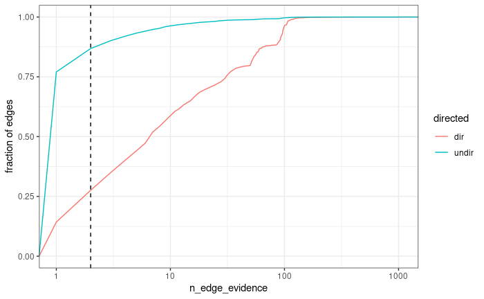

```r
net.tbl %>%
  mutate(directed = if_else(interaction %in% directed_edge_types, 'dir','undir') ) %>%
  ggplot(aes(n_edge_evidence))+
  stat_ecdf(geom = 'line', aes(color = directed))+
  # geom_density(aes(fill = directed))+
  # geom_histogram(aes(fill = directed), position = position_dodge())+
  # scale_y_log10()+
  scale_x_log10()+
  geom_vline(xintercept = 2, lty = 2, lwd = .5)+
  labs(y = 'fraction of edges')
```

Distribution of evidence support for edges

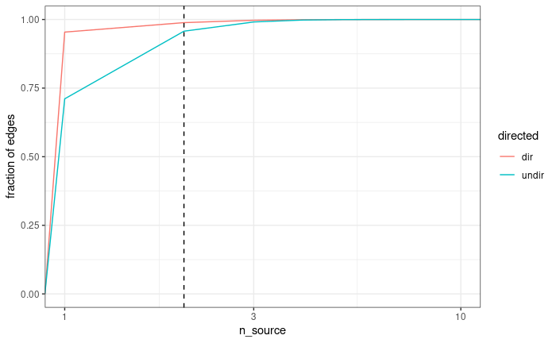

```r
net.tbl %>%
  mutate(directed = if_else(interaction %in% directed_edge_types, 'dir','undir') ) %>%
  ggplot(aes(n_source))+
  stat_ecdf(geom = 'line', aes(color = directed))+
  # geom_density(aes(fill = directed))+
  # geom_histogram(aes(fill = directed), position = position_dodge())+
  # scale_y_log10()+
  scale_x_log10()+
  geom_vline(xintercept = 2, lty = 2, lwd = .5)+
  labs(y = 'fraction of edges')
```

Distribution of evidence support for edges

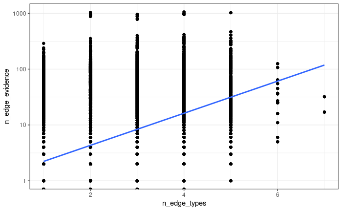

```r
net.tbl %>%
  # mutate(directed = if_else(interaction %in% directed_edge_types, 'dir','undir') ) %>%
  ggplot(aes( n_edge_types, n_edge_evidence ))+
  geom_point()+
  geom_smooth(method = 'lm')+
  scale_y_log10()+
  # scale_x_log10()+
  # geom_vline(xintercept = 2, lty = 2, lwd = .5)+
  labs()
```

# Human Protein Atlas

Specify brain tissue types

```r
brain.tissues <- c(
 "caudate", "cerebellum", "cerebral cortex", "hippocampus",
 "hypothalamus", "pituitary gland", "dorsal raphe",
 "choroid plexus", "substantia nigra"
)

brain.genes <- tissue.array %>% filter(
  Tissue %in% brain.tissues,
  Level %in% c('Low','Medium','High','Ascending','Descending'),
  Reliability %in% c('Enhanced','Supported','Approved')
) %>% pull(Gene.name) %>% unique()

not.brain <- tissue.array %>% filter(
  Tissue %in% brain.tissues,
  Level %in% c('Not detected'),
  Reliability %in% c('Enhanced','Supported','Approved')
) %>% pull(Gene.name) %>% unique()
```

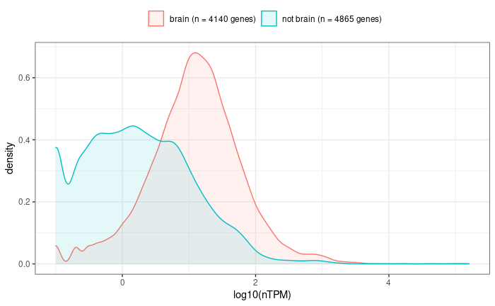

```r
# also "brain genes":
# scores %>% filter(isScored_omics == 'Y', OmicsScore > 0) %>% pull(GeneName) %>% unique()

brain.gtex %>%
  mutate(hpa = case_when(Gene.name %in% brain.genes ~
                           paste0('brain (n = ', length(intersect(Gene.name, brain.genes)),' genes)'),
                         Gene.name %in% not.brain ~
                           paste0('not brain (n = ', length(intersect(Gene.name,not.brain)),' genes)'),
                         T ~ NA_character_)) %>%
  filter(!is.na(hpa)) %>%
  ggplot(aes( log10(nTPM), fill = hpa))+
  geom_density(aes(color = hpa), alpha = .1)+
  # geom_histogram(position = 'dodge')+
  # scale_y_log10()+
  scale_fill_discrete('')+scale_color_discrete('')+
  theme(legend.position = 'top')
```

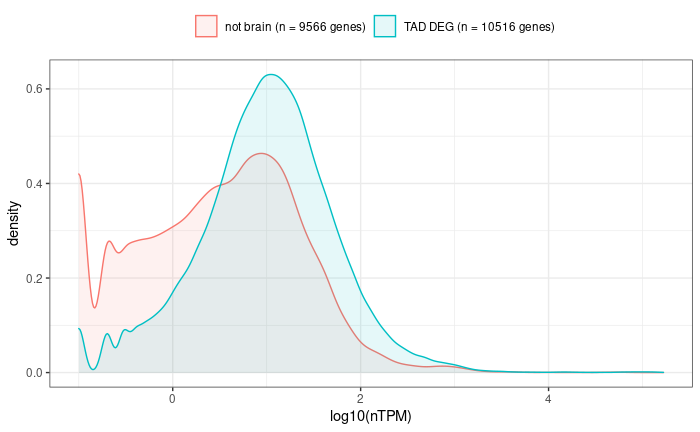

```r
# also "brain genes":
tad.deg <- scores %>% filter(isScored_omics == 'Y', OmicsScore > 0) %>% pull(GeneName) %>% unique()

brain.gtex %>%
  mutate(hpa = case_when(Gene.name %in% tad.deg ~ paste0('TAD DEG (n = ', length(intersect(Gene.name,tad.deg)),' genes)'),
                         T ~ paste0('not brain (n = ', length(setdiff(Gene.name, tad.deg)),' genes)'),
                         )) %>%
  filter(!is.na(hpa)) %>%
  ggplot(aes( log10(nTPM), fill = hpa))+
  geom_density(aes(color = hpa), alpha = .1)+
  # geom_histogram(position = 'dodge')+
  # scale_y_log10()+
  scale_fill_discrete('')+scale_color_discrete('')+
  theme(legend.position = 'top')
```

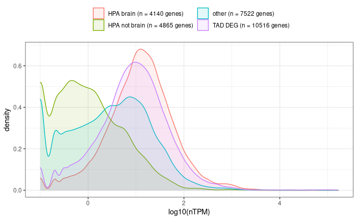

```r
# also "brain genes":
tad.deg <- scores %>% filter(isScored_omics == 'Y', OmicsScore > 0) %>% pull(GeneName) %>% unique()

brain.gtex %>%
  mutate(hpa = case_when(Gene.name %in% brain.genes ~
                           paste0('HPA brain (n = ', length(intersect(Gene.name, brain.genes)),' genes)'),
                         Gene.name %in% tad.deg ~ paste0('TAD DEG (n = ', length(intersect(Gene.name,tad.deg)),' genes)'),
                         Gene.name %in% not.brain ~ paste0('HPA not brain (n = ', length(intersect(Gene.name,not.brain)),' genes)'),
                         T ~
                           paste0('other (n = ', length(setdiff(Gene.name, union(union(brain.genes, tad.deg), not.brain))) ,' genes)'),
                         )) %>%
  filter(!is.na(hpa)) %>%
  ggplot(aes( log10(nTPM), fill = hpa))+
  geom_density(aes(color = hpa), alpha = .1)+
  # geom_histogram(position = 'dodge')+
  # scale_y_log10()+
  scale_fill_discrete('')+scale_color_discrete('')+
  guides(fill = guide_legend(nrow=2))+
  theme(legend.position = 'top')
```

# SEA-AD single cell data

```r
seaad <- read_csv(synGet('syn51080312')$path, guess_max = 2e5)
```

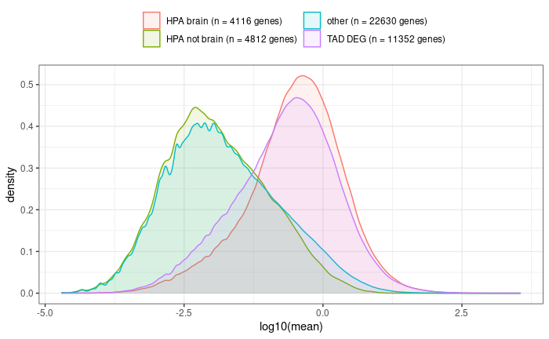

```r
# also "brain genes":
# scores %>% filter(isScored_omics == 'Y', OmicsScore > 0) %>% pull(GeneName) %>% unique()

seaad %>%
  # filter(is.na(group)) %>%
  mutate(
    hpa = case_when(
      gene %in% brain.genes ~ paste0('HPA brain (n = ', length(intersect(gene, brain.genes)),' genes)'),
      gene %in% tad.deg ~ paste0('TAD DEG (n = ', length(intersect(gene,tad.deg)),' genes)'),
      gene %in% not.brain ~ paste0('HPA not brain (n = ', length(intersect(gene,not.brain)),' genes)'),
      T ~ paste0('other (n = ', length(unique(setdiff(gene, union(union(brain.genes, tad.deg), not.brain)))) ,' genes)')
      )
  ) %>%
  filter(!is.na(hpa)) %>%
  ggplot(aes( log10(mean), fill = hpa))+
  geom_density(aes(color = hpa), alpha = .1)+
  # geom_histogram(position = 'dodge')+
  # scale_y_log10()+
  scale_fill_discrete('')+scale_color_discrete('')+
  guides(fill = guide_legend(nrow=2))+
  theme(legend.position = 'top')
```

```r
seaad$gene %>% unique() %>% length() %>% print()
```

[output not shown]

# Pairwise partial correlations

Specify Enesmbl IDs of brain gene lists

```r
brain.genes.ensg <-
  tissue.array %>% filter(
    Tissue %in% brain.tissues,
    Level %in% c('Low','Medium','High','Ascending','Descending'),
    Reliability %in% c('Enhanced','Supported','Approved')) %>%
    pull(Gene) %>% unique()


not.brain.ensg <- tissue.array %>% filter(
  Tissue %in% brain.tissues,
  Level %in% c('Not detected'),
  Reliability %in% c('Enhanced','Supported','Approved')
) %>% pull(Gene) %>% unique()

tad.deg.ensg <- scores %>% filter(isScored_omics == 'Y', OmicsScore > 0) %>% pull(ENSG) %>% unique()
```

Load ROSMAP pairwise partial correlations

```r
rm.pcor <- read_csv(synGet('syn51061790')$path) %>%
  rename(gene1 = X1) %>%
  pivot_longer(cols = -gene1, names_to = 'gene2', values_to = 'pcor') %>%
  filter(pcor < 1)
```

Classify pairs based on HPA expression and TREAT-AD DEG status

```r
rm.pcor <- rm.pcor %>%
  mutate(
    brain = case_when(
      (gene1 %in% brain.genes.ensg & gene2 %in% brain.genes.ensg) ~ 'yes, both',
      (gene1 %in% not.brain.ensg & gene2 %in% not.brain.ensg) ~ 'no, both',
      (gene1 %in% brain.genes.ensg | gene2 %in% brain.genes.ensg) ~ 'yes, one',
      (gene1 %in% not.brain.ensg | gene2 %in% not.brain.ensg) ~ 'no, one',
      T ~ 'other'
    ),
    tad.deg = case_when(
      (gene1 %in% tad.deg.ensg & gene2 %in% tad.deg.ensg) ~ 'yes, both',
      (gene1 %in% tad.deg.ensg | gene2 %in% tad.deg.ensg) ~ 'yes, one',
      !(gene1 %in% tad.deg.ensg & gene2 %in% tad.deg.ensg) ~ 'no, both',
      T ~ 'other'
    )
  )
```

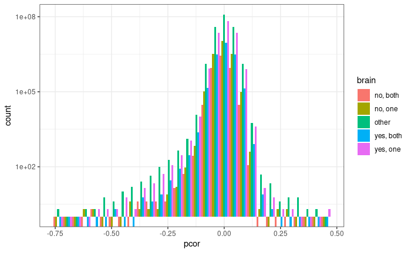

```r
rm.pcor %>%
  ggplot( aes(pcor))+
  scale_y_log10()+
  # geom_density()
  geom_histogram(aes(fill = brain), position = 'dodge')
```

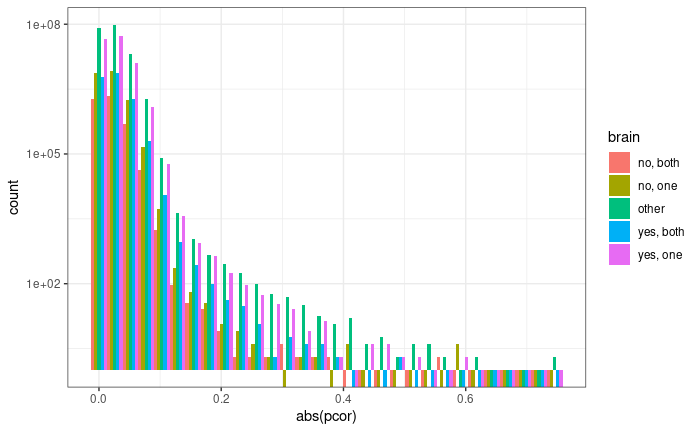

```r
rm.pcor %>%
  ggplot( aes( abs(pcor), fill = brain) )+
  scale_y_log10()+
  # geom_density(aes(color = brain), alpha = 0.1 )
  geom_histogram(aes(fill = brain), position = 'dodge')
```

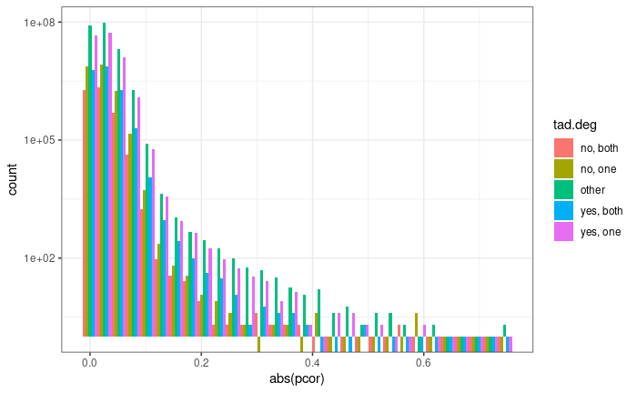

```r
rm.pcor %>%
  ggplot( aes( abs(pcor), fill = tad.deg))+
  scale_y_log10()+
  # geom_density(aes(color = tad.deg), alpha = 0.1 )
  geom_histogram(aes(fill = brain), position = 'dodge')
```

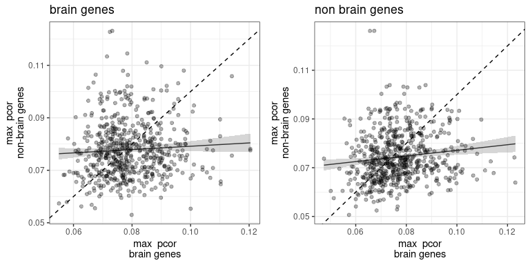

```r
x = rm.pcor %>%
     filter(gene1 %in% setdiff(brain.genes.ensg, not.brain.ensg)) %>%
     group_by(gene1) %>%
     summarise(
         mean_bg = max((pcor[gene2 %in% setdiff(brain.genes.ensg, not.brain.ensg)]), na.rm = T),
         mean_nbg = max((pcor[gene2 %in% setdiff(not.brain.ensg, brain.genes.ensg)]), na.rm = T)
     )
y = rm.pcor %>%
     filter(gene1 %in% setdiff(not.brain.ensg, brain.genes.ensg)) %>%
     group_by(gene1) %>%
     summarise(
         mean_bg = max((pcor[gene2 %in% setdiff(brain.genes.ensg, not.brain.ensg)]), na.rm = T),
         mean_nbg = max((pcor[gene2 %in% setdiff(not.brain.ensg, brain.genes.ensg)]), na.rm = T)
     )

cowplot::plot_grid(
    ggplot(x, aes(mean_bg, mean_nbg)) +
        geom_abline(intercept = 0, slope = 1, lty = 2, lwd = .5)+
        geom_smooth(method = 'lm', lwd = .5, color = 'grey20')+
        # coord_cartesian(xlim = c(0.05,0.15), ylim = c(0.05,0.15))+
      geom_point( alpha = .3 )+
        labs(title = 'brain genes', x = 'max  pcor\nbrain genes', y = 'max  pcor\nnon-brain genes'),
    ggplot(y, aes(mean_bg, mean_nbg)) +
        geom_abline(intercept = 0, slope = 1, lty = 2, lwd = .5)+
        geom_smooth(method = 'lm', lwd = .5, color = 'grey20')+
        # coord_cartesian(xlim = c(0.05,0.15), ylim = c(0.05,0.15))+
      geom_point( alpha = .3 )+
        labs(title = 'non brain genes', x = 'max  pcor\nbrain genes', y = 'max  pcor\nnon-brain genes')
)
```